# Sprawozdanie 1

Adrian Pilarczyk i Diana Popiel

Matematyka Stosowana

## Zadanie 1.

Wygeneruj 3 próby z rozkładu Gamma z wybranymi przez siebie (różnymi) parametrami $k, \lambda$. Porównaj otrzymane średnie i wariancje w próbach z wartościami teoretycznymi. Narysuj histogram każdej z prób i porównaj go z teoretyczną gęstością. Narysuj również teoretyczne dystrybuanty rozważanych zmiennych (najlepiej wszystkie 3 na jednym obrazku dla porównania).

```r
k1 <- 2
lam1 <- 4
k2 <- 7
lam2 <- 3
k3 <- 15
lam3 <- 9

sample1 <- rgamma(1000, shape = k1, rate = lam1)
sample2 <- rgamma(1000, shape = k2, rate = lam2)
sample3 <- rgamma(1000, shape = k3, rate = lam3)
```

```r
sample_mean1 <- mean(sample1)
sample_var1 <- var(sample1)
sample_mean2 <- mean(sample2)
sample_var2 <- var(sample2)
sample_mean3 <- mean(sample3)
sample_var3 <- var(sample3)
```

Teoretyczna wartość oczekiwana zmiennej o rozkładzie Gamma wynosi $\frac{k}{\lambda}$, a wariancja $\frac{k}{\lambda^2}$. Korzystamy z powyższych wzorów dla każdej z 3 próbek:

```r
theor_mean1 <- k1/lam1
theor_var1 <- k1/(lam1^2)
theor_mean2 <- k2/lam2
theor_var2 <- k2/(lam2^2)
theor_mean3 <- k3/lam3
theor_var3 <- k3/(lam3^2)
```

```r
x <- seq(0, 6, length = 1000)
den_sample1 <- dgamma(sample1, k1, lam1)
den_sample2 <- dgamma(sample2, k2, lam2)
den_sample3 <- dgamma(sample3, k3, lam3)
```

Histogram dla pierwszej próbki:

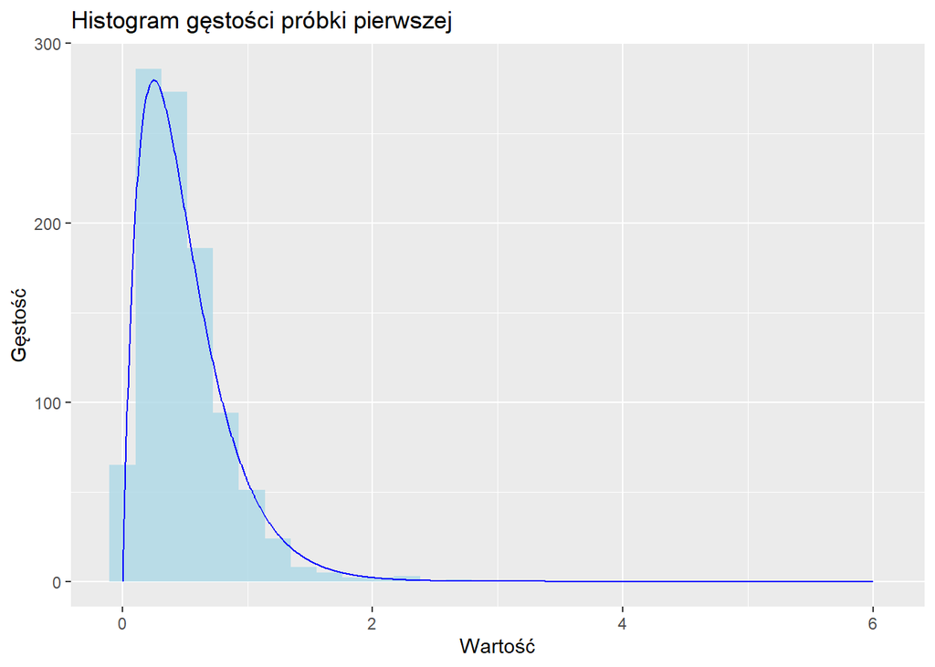

```r
wykres1<- ggplot() +
  geom_histogram(aes(x = sample1), bins = 30, fill = "lightblue", alpha = 0.8) +
  geom_line(aes(x = x, y = 190*dgamma(x,k1,lam1)), color = "blue") +
  labs(title='Histogram gęstości próbki pierwszej', x='Wartość', y='Gęstość')
wykres1
```

Histogram dla drugiej próbki:

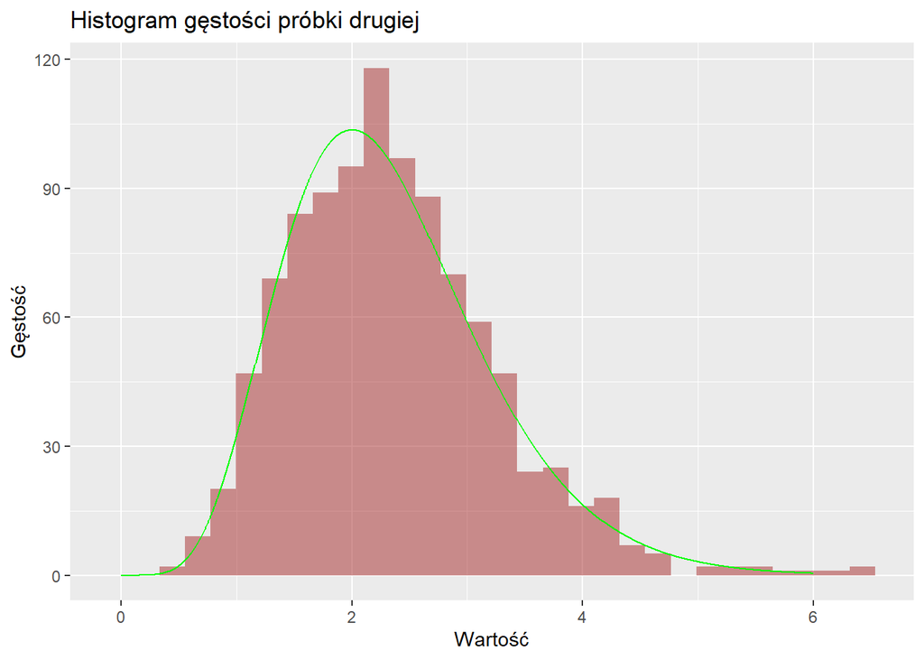

```r
wykres2<- ggplot() +
  geom_histogram(aes(x = sample2), bins = 30, fill = "brown", alpha = 0.5) +
  geom_line(aes(x = x, y = 215*dgamma(x,k2,lam2)), color = "green") +
  labs(title='Histogram gęstości próbki drugiej', x='Wartość', y='Gęstość')
wykres2
```

Histogram dla trzeciej próbki:

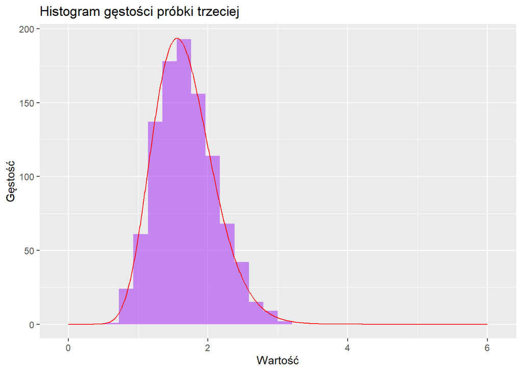

```r
wykres3<- ggplot() +
  geom_histogram(aes(x = sample3), bins = 30, fill = "purple", alpha = 0.5) +
  geom_line(aes(x = x, y = 203*dgamma(x,k3,lam3)), color = "red") +
  labs(title='Histogram gęstości próbki trzeciej', x='Wartość', y='Gęstość')
wykres3
```

Widzimy, że powyższe histogramy próbek oraz ich teoretyczne gęstości (pomnożone dla lepszej widoczności na wykresie) są ze sobą zbliżone. Następnie poniżej mamy wykres z poszczególnymi dystrybuantami:

Dystrybuanta 1 rozkładu gamma z parametrami $k_1=2$ i $\lambda = 4$ (kolor zielony na wykresie).

Dystrybuanta 2 rozkładu gamma z parametrami $k_2=7$ i $\lambda = 3$ (kolor pomarańczowy na wykresie).

Dystrybuanta 3 rozkładu gamma z parametrami $k_3=15$ i $\lambda = 9$ (kolor czerwony na wykresie).

```r
dist1<-pgamma(x, k1, lam1)
dist2<-pgamma(x, k2, lam2)
dist3<-pgamma(x, k3, lam3)
```

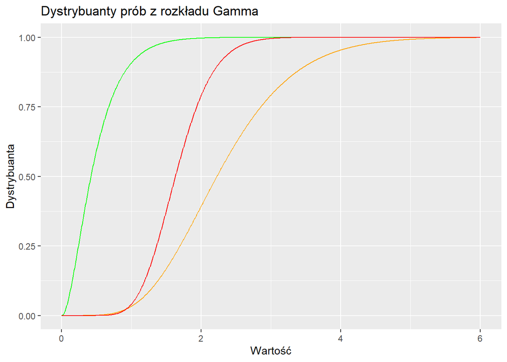

```r
dist_plot <- ggplot() + geom_line(aes(x = x, y = dist1), color = "green") + geom_line(aes(x = x, y = dist2), color = "orange") + geom_line(aes(x = x, y = dist3), color = "red") +
  labs(title='Dystrybuanty prób z rozkładu Gamma', x='Wartość', y='Dystrybuanta')
dist_plot
```

## Zadanie 2.

Zweryfikuj empirycznie (np. za pomocą wykresu gęstości), że rozkład wykładniczy z parametrem $\lambda$ jest szczególnym przypadkiem rozkładu Gamma z parametrami $\lambda$ i $k=1$.

Rozkład wykładniczy z parametrem $\lambda$ może być interpretowany jako szczególny przypadek rozkładu Gamma z parametrami $\lambda$ i $k=1$. Aby to zweryfikować, można wygenerować próbę z rozkładu Gamma z parametrami $\lambda=1$ i $k=1$, a następnie porównać ją z próbą z rozkładu wykładniczego z tym samym parametrem $\lambda$.

```r
sample_gamma <- rgamma(1000, shape = 1, rate = 1)
sample_exp <- rexp(1000, rate = 1)
den_sample_gamma <- dgamma(sample_gamma, shape = 1, rate = 1)
den_sample_exp <-dexp(sample_exp, rate = 1)
```

Następnie rysujemy wykres gęstości rozkładu Gamma (niebieski) oraz gęstości rozkładu wykładniczego (czerowny).

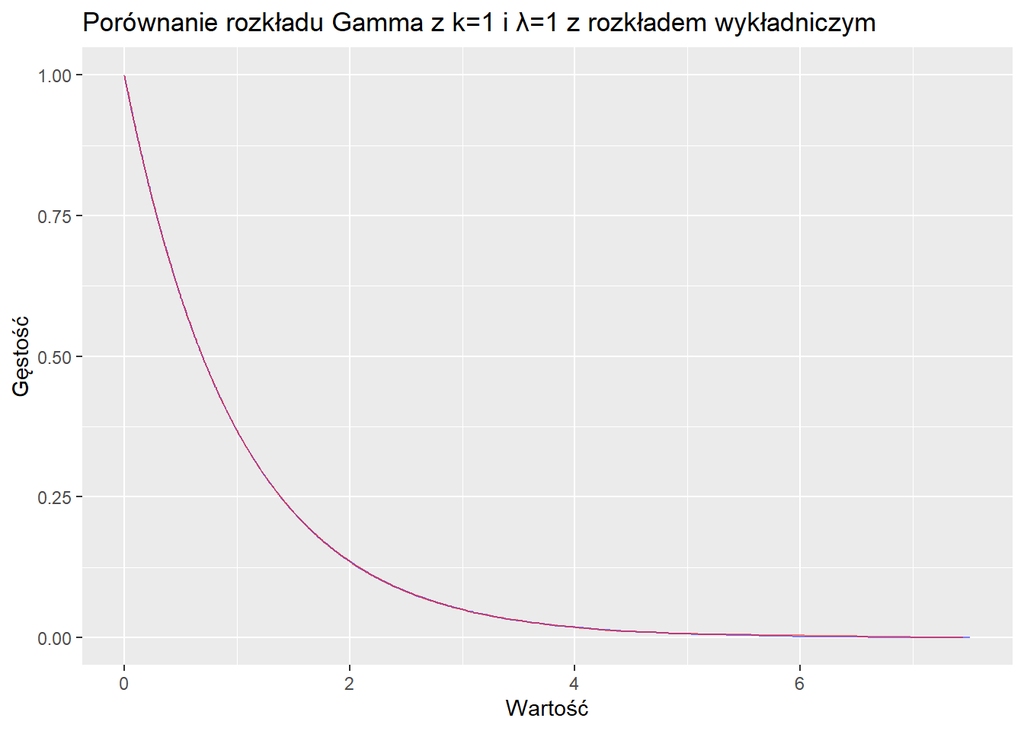

```r
gamma_exp_same_plot <- ggplot()+geom_line(aes(x = sample_gamma, y = den_sample_gamma), color = "blue", alpha = 0.5) +
  geom_line(aes(x = sample_exp, y = den_sample_exp), color = "red", alpha = 0.5) +
  labs(title='Porównanie rozkładu Gamma z k=1 i λ=1 z rozkładem wykładniczym', x='Wartość', y='Gęstość')
gamma_exp_same_plot
```

Widzimy, że wykresy gęstości obu próbek się ze sobą nakładają. Oznacza to że rozkład wykładniczy jest specjalnym przypadkiem rozkładu Gamma z odpowiednimi parametrami $\lambda$ oraz $k=1$.

## Zadanie 3.

Zweryfikuj empirycznie (np. za pomocą wykresów gęstości), że suma $k$ niezależnych zmiennych o rozkładzie wykładniczym z tym samym parametrem $\lambda$ ma rozkład Gamma z parametrami $\lambda$, $k$.

Dla potrzeb zadania, ustalamy sobie dowolne $k=12$ i $\lambda = 1$. Wyznaczamy funkcje, która generuje wektor próbek zależnych od ilości $k$. Następnie rozwijamy wektor w macierz i sumujemy ją po rzędach, aby uzyskać naszą próbkę złożoną z sum $k$ niezależnych zmiennych.

```r
k = 12
lambd = 1
list_of_exp_samples <- vector("list", k)
for (i in 1:k) {
  list_of_exp_samples[[i]] <- rexp(1000, rate = lambd)
}
list_of_exp_samples_matrix <- matrix(unlist(list_of_exp_samples), nrow = 1000, ncol = k, byrow = FALSE)

sum_of_exp_samples_matrix <- rowSums(list_of_exp_samples_matrix)
```

Wyznaczamy odpowiednie gęstości. Rysujemy poszczególne wykresy: gęstości sumy niezależnych zmiennych z rozkładu wykładczniego (kolor czerwony) oraz z rozkładu Gamma (kolor zielony).

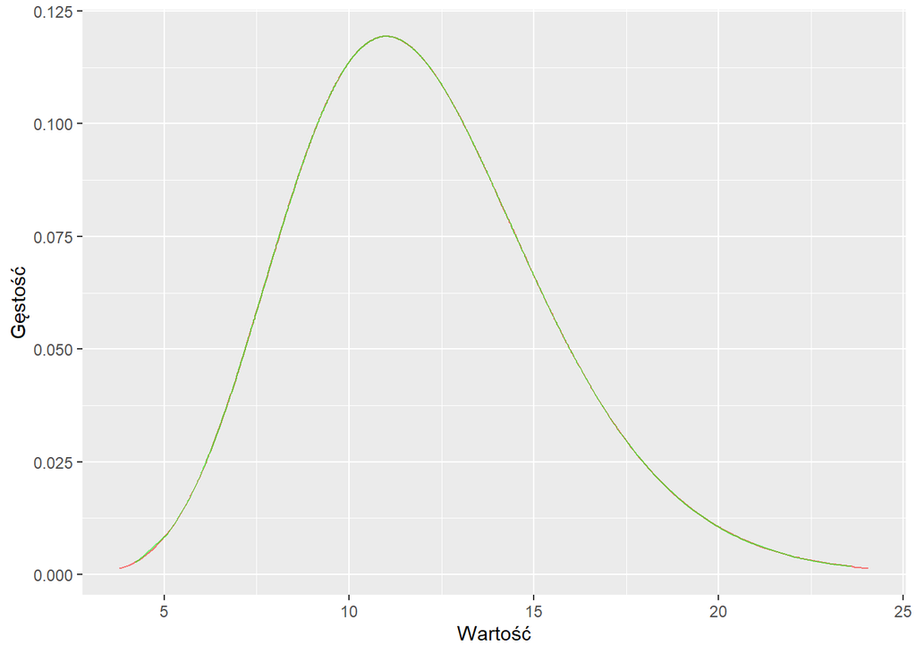

```r
gamma_sample_from_exp <- rgamma(1000, k, lambd)

sum_of_exp_density <- dgamma(sum_of_exp_samples_matrix, k, lambd)
gamma_sample_from_exp_density <- dgamma(gamma_sample_from_exp, k, lambd)

gamma_exp_plot <- ggplot() +
  geom_line(aes(x=sum_of_exp_samples_matrix, y=sum_of_exp_density), color="red", alpha = 0.5) +
  geom_line(aes(x=gamma_sample_from_exp, y=gamma_sample_from_exp_density), color="green", alpha = 0.5) +
  labs(tittle="Wykres gęstości rozkładu Gamma oraz gęstości sumy niezależnych zmiennych z rozkładu wykładniczego",x = "Wartość", y = "Gęstość")

gamma_exp_plot
```

## Zadanie 4.

Zweryfikuj empirycznie (np. za pomocą wykresów gęstości) stwierdzenie, że jeżeli zmienna $X$ ma rozkład Gamma z parametrami $\lambda$,$k$, to zmienna $cX$ (dla pewnego $c>0$) ma rozkład Gamma o parametrach $\frac{\lambda}{c}$, $k$.

Dla tego zadania dobieramy sobie dowolne $\lambda=6$ i $k=3$. Następnie wyznaczamy pierwszą próbkę z rozkładu gamma a później mnożymy ją przez nasz parametr $c=2$, aby uzyskać drugą próbkę z tego rozkładu.

```r
lambda4 <- 6
k4 <- 3

x <- rgamma(1000, k4, lambda4)
c <- 2
y <- c*x
```

Następnie wyznaczamy odpowiednie gęstości z tych próbek i tworzymy dwa wykresy, aby porównać ich zachowanie.

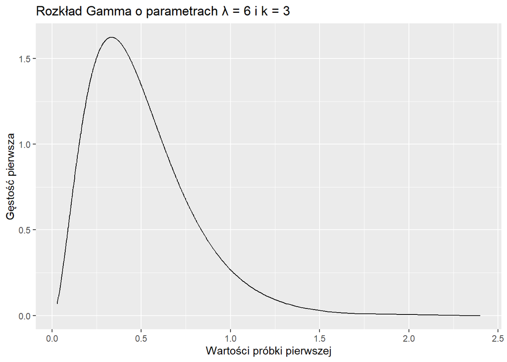

```r
first_density <- dgamma(x, k4, lambda4)
second_density <- dgamma(y, k4, lambda4)

ggplot() + geom_line(aes(x=x, y=first_density)) +
  ggtitle(paste("Rozkład Gamma o parametrach λ =", lambda4, "i k =", k4)) +
  xlab("Wartości próbki pierwszej") +  ylab("Gęstość pierwsza")
```

[figure not shown]

```r
ggplot() + geom_line(aes(x=y, y=second_density)) +
  ggtitle(paste("Rozkład Gamma o parametrach λ =", lambda4/c, "i k =", k4)) +
  xlab("Wartości próbki drugiej") + ylab("Gęstość druga")
```

## Zadanie 5*.

Porównaj próby z rozkładu Gamma z ustalonym parametrem $\lambda$ i *dużymi* parametrami $k$ (proponuje $k > 50$) i próby z rozkładu normalnego ze średnią $\frac{k}{\lambda}$ i wariancją $\frac{k}{\lambda^2}$.

Dla dowolnej $\lambda = 2$ oraz $k=100$ generujemy próbkę z rozkładu gamma oraz wyznaczamy jej gęstość.

```r
lambda <- 2
k <- 100

x <- rgamma(10000, k, lambda)
gamma_density <- dgamma(x, k, lambda)
```

Następnie wyznaczamy średnią i wariancję z rozkładu normalnego posługując się $\lambda$ i $k$. Dzięki temu możemy wygenerować próbkę z rozkładu normalnego oraz jej gęstość, używając nowych parametrów $m$ i $sigma$. Na końcu rysujemy dwa wykresy porównujące te dwie próbki i ich gęstości.

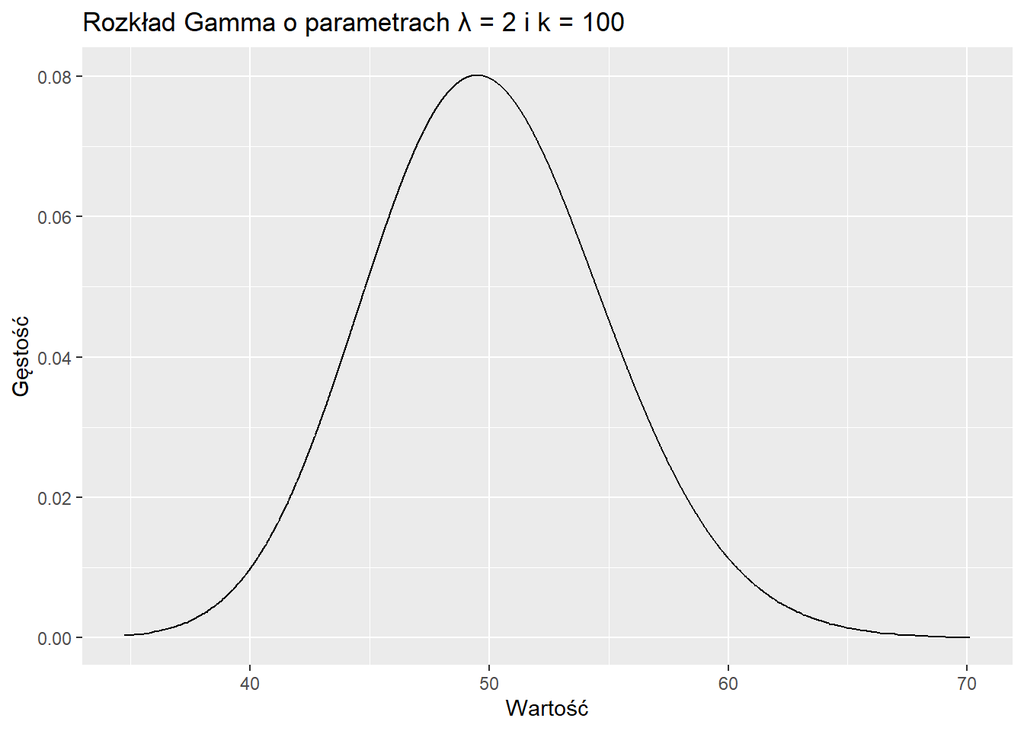

```r
m <- k/lambda
sigma <- sqrt(k)/lambda

y <- rnorm(10000, m, sigma)
norm_density <- dnorm(y, m, sigma)

ggplot() +
  geom_line(aes(x=x, y=gamma_density)) +
  ggtitle(paste("Rozkład Gamma o parametrach λ =", lambda, "i k =", k)) +
  xlab("Wartość") + ylab("Gęstość")
```

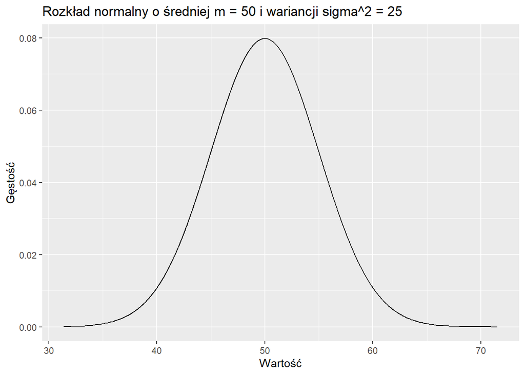

```r
ggplot() +
  geom_line(aes(x=y, y=norm_density)) +
  ggtitle(paste("Rozkład normalny o średniej m =", m, "i wariancji sigma^2 =", sigma^2)) +
  xlab("Wartość") + ylab("Gęstość")
```

Na powyższych wykresach można zauważyć, że rozkład Gamma z dużymi parametrami $k$ wygląda podobnie do rozkładu normalnego o odpowiedniej wyliczonej średniej i wariancji. Można więc stwierdzić, że dla dużych wartości parametru $k$, rozkład Gamma zaczyna przypominać rozkład normalny ze średnią $\frac{k}{\lambda}$ i wariancją $\frac{k}{\lambda^2}$.